# Poverty and Test Performance in New York Public Schools

Danfeng Li, NYC Department of Education

9月 21, 2026

## The question

The department asked: **what can data tell us about the relationship between poverty and test performance in New York public schools?**, plus three follow-ups: how big is the gap between low/medium/high poverty areas, has it changed over time, and is it moderated by access to free/reduced-price lunch.

**Why this matters:** answers here shape where the department targets resources (funding, staffing, program design) and whether current interventions are narrowing or widening outcome gaps. Getting the poverty measure and the score comparison wrong could send resources to the wrong places or hide/mask a trend that’s already improving.

**Before touching the data**, the plan was to (1) build one county-poverty measure and split it into interpretable tiers, (2) make test scores comparable across years despite NYS changing the underlying tests, (3) compare scores across poverty tiers overall, by year, and by school-level lunch access. The expectation going in: a negative poverty-performance relationship, similar in direction to well-documented national patterns, with the open questions being *how large*, *whether it’s moving*, and *whether county poverty or school-level need does more of the work*.

## Data

Two raw sources, joined by `county_name` and `year`:

- `data/data_raw/nys_schools.csv` — school-level enrollment, free/reduced lunch %, and mean ELA/math scores, 2008–2017.
- `data/data_raw/nys_acs.csv` — county-level poverty rate, median household income, and % with a bachelor’s degree, 2009–2016.

```r
schools_raw <- read_csv("data/data_raw/nys_schools.csv", show_col_types = FALSE)
acs_raw <- read_csv("data/data_raw/nys_acs.csv", show_col_types = FALSE)
```

### Cleaning

Missing values are coded as `-99` in both numeric and character columns of the school data (e.g. `mean_math_score`, but also `county_name` itself for a handful of rows). We recode both types to `NA` with one generic sweep rather than hardcoding column names:

```r
recode_missing <- function(df) {
  df %>%
    mutate(across(where(is.character), ~ na_if(.x, "-99")),
           across(where(is.numeric), ~ na_if(.x, -99)))
}

schools_clean <- recode_missing(schools_raw)
acs_clean <- recode_missing(acs_raw)

nys <- schools_clean %>% left_join(acs_clean, by = c("county_name", "year"))
```

### Poverty tiers

We split county poverty rate (`county_per_poverty`) into **terciles** — low / medium / high — computed across all county-year observations:

```r
poverty_cuts <- quantile(acs_clean$county_per_poverty, probs = c(1/3, 2/3), na.rm = TRUE)

nys <- nys %>%
  mutate(
    poverty_group = case_when(
      is.na(county_per_poverty) ~ NA_character_,
      county_per_poverty <= poverty_cuts[1] ~ "low",
      county_per_poverty <= poverty_cuts[2] ~ "medium",
      TRUE ~ "high"
    ),
    poverty_group = factor(poverty_group, levels = c("low", "medium", "high"))
  )
```

**Why terciles:** they split the counties into three roughly equal-sized groups using the data’s own distribution, rather than an arbitrary rate threshold (e.g. “poverty > 20%”) that has no particular basis for New York specifically.

### Comparable scores across years

NYS changed the underlying tests over this period, so raw scale scores aren’t comparable year to year. We standardize math and ELA scores to z-scores *within each year*:

```r
nys <- nys %>%
  group_by(year) %>%
  mutate(z_math = as.numeric(scale(mean_math_score)),
         z_ela = as.numeric(scale(mean_ela_score))) %>%
  ungroup()
```

Note: ACS poverty data only covers 2009–2016, while school data runs 2008–2017, so `poverty_group` is `NA` for 2008 and 2017 school records — those two years are excluded from any poverty-tier comparison below.

*(Full cleaning script: `scripts/1_cleaned.R`.)*

## Summary tables

*(Built in `scripts/2_summary_tables.R`; loaded here from the saved output for speed.)*

**County profile** — enrollment, lunch access, and poverty rate for every county (highest-poverty first):

```r
read_csv("data/processed/tables/1_county_profile.csv", show_col_types = FALSE) %>%
  kable(digits = 3, col.names = c("County", "Avg. annual enrollment", "% free/reduced lunch", "% in poverty"))
```

| County | Avg. annual enrollment | % free/reduced lunch | % in poverty |
| --- | --- | --- | --- |
| BRONX | 164613 | 0.859 | 0.287 |
| KINGS | 231798 | 0.771 | 0.224 |
| MONTGOMERY | 4959 | 0.537 | 0.178 |
| CHAUTAUQUA | 13328 | 0.541 | 0.175 |
| TOMPKINS | 7988 | 0.396 | 0.175 |
| NEW YORK | 104857 | 0.682 | 0.172 |
| CATTARAUGUS | 9370 | 0.509 | 0.165 |
| SULLIVAN | 6441 | 0.519 | 0.164 |
| SAINT LAWRENCE | 11019 | 0.521 | 0.164 |
| OSWEGO | 13689 | 0.502 | 0.162 |
| FULTON | 5536 | 0.520 | 0.161 |
| BROOME | 19342 | 0.476 | 0.159 |
| FRANKLIN | 4918 | 0.561 | 0.156 |
| ALLEGANY | 5590 | 0.519 | 0.151 |
| ONEIDA | 22929 | 0.525 | 0.149 |
| CHEMUNG | 8776 | 0.489 | 0.149 |
| STEUBEN | 10443 | 0.492 | 0.148 |
| OTSEGO | 5902 | 0.436 | 0.147 |
| CHENANGO | 5387 | 0.541 | 0.145 |
| JEFFERSON | 13585 | 0.470 | 0.142 |
| YATES | 1469 | 0.552 | 0.141 |
| MONROE | 75886 | 0.446 | 0.140 |
| ERIE | 92605 | 0.471 | 0.140 |
| QUEENS | 202569 | 0.727 | 0.140 |
| ONONDAGA | 47504 | 0.443 | 0.139 |
| HERKIMER | 6432 | 0.506 | 0.139 |
| DELAWARE | 4659 | 0.526 | 0.139 |
| LEWIS | 3083 | 0.485 | 0.136 |
| CORTLAND | 3703 | 0.494 | 0.134 |
| CLINTON | 7433 | 0.445 | 0.132 |
| NIAGARA | 19972 | 0.465 | 0.130 |
| ORLEANS | 4027 | 0.512 | 0.128 |
| ROCKLAND | 27349 | 0.389 | 0.127 |
| GREENE | 4421 | 0.414 | 0.127 |
| ALBANY | 25719 | 0.388 | 0.123 |
| GENESEE | 5010 | 0.423 | 0.121 |
| LIVINGSTON | 5838 | 0.378 | 0.119 |
| WASHINGTON | 5668 | 0.441 | 0.119 |
| ULSTER | 15727 | 0.400 | 0.118 |
| RENSSELAER | 13721 | 0.407 | 0.118 |
| SCHENECTADY | 15258 | 0.456 | 0.117 |
| ORANGE | 41228 | 0.388 | 0.117 |
| SENECA | 2883 | 0.428 | 0.115 |
| CAYUGA | 5846 | 0.427 | 0.115 |
| RICHMOND | 43191 | 0.562 | 0.114 |
| WAYNE | 9993 | 0.447 | 0.113 |
| SCHOHARIE | 3291 | 0.453 | 0.113 |
| SCHUYLER | 1155 | 0.453 | 0.110 |
| ESSEX | 3001 | 0.469 | 0.110 |
| WARREN | 6460 | 0.355 | 0.108 |
| HAMILTON | 512 | 0.348 | 0.104 |
| MADISON | 6750 | 0.409 | 0.100 |
| COLUMBIA | 4816 | 0.416 | 0.099 |
| WYOMING | 2312 | 0.399 | 0.097 |
| TIOGA | 5309 | 0.492 | 0.096 |
| ONTARIO | 11143 | 0.330 | 0.093 |
| WESTCHESTER | 104167 | 0.346 | 0.089 |
| DUTCHESS | 26248 | 0.326 | 0.084 |
| SARATOGA | 22698 | 0.201 | 0.064 |
| SUFFOLK | 163856 | 0.401 | 0.062 |
| PUTNAM | 10107 | 0.145 | 0.058 |
| NASSAU | 133651 | 0.231 | 0.056 |
| NA | 654 | 0.782 | NA |

**Top 5 / bottom 5 poverty counties** — raw and standardized scores side by side:

```r
read_csv("data/processed/tables/2_top_bottom_poverty_counties.csv", show_col_types = FALSE) %>%
  kable(digits = 3, col.names = c("Group", "County", "% poverty", "% free/reduced lunch",
                                   "Mean ELA", "Mean math", "Mean ELA z", "Mean math z"))
```

| Group | County | % poverty | % free/reduced lunch | Mean ELA | Mean math | Mean ELA z | Mean math z |
| --- | --- | --- | --- | --- | --- | --- | --- |
| Top 5 (highest poverty) | BRONX | 0.287 | 0.859 | 463.005 | 470.463 | -0.768 | -0.703 |
| Top 5 (highest poverty) | KINGS | 0.224 | 0.771 | 469.059 | 477.823 | -0.272 | -0.227 |
| Top 5 (highest poverty) | MONTGOMERY | 0.178 | 0.537 | 481.177 | 490.824 | -0.498 | -0.424 |
| Top 5 (highest poverty) | CHAUTAUQUA | 0.175 | 0.541 | 484.267 | 494.787 | -0.234 | -0.154 |
| Top 5 (highest poverty) | TOMPKINS | 0.175 | 0.396 | 483.689 | 492.513 | 0.071 | 0.000 |
| Bottom 5 (lowest poverty) | NASSAU | 0.056 | 0.231 | 498.146 | 509.590 | 0.888 | 0.821 |
| Bottom 5 (lowest poverty) | PUTNAM | 0.058 | 0.145 | 504.912 | 516.337 | 0.660 | 0.614 |
| Bottom 5 (lowest poverty) | SUFFOLK | 0.062 | 0.401 | 491.414 | 501.373 | 0.363 | 0.316 |
| Bottom 5 (lowest poverty) | SARATOGA | 0.064 | 0.201 | 493.332 | 503.461 | 0.631 | 0.525 |
| Bottom 5 (lowest poverty) | DUTCHESS | 0.084 | 0.326 | 494.265 | 501.968 | 0.090 | -0.057 |

**Performance by poverty tier:**

```r
read_csv("data/processed/tables/3_performance_by_poverty_group.csv", show_col_types = FALSE) %>%
  kable(digits = 3, col.names = c("Poverty tier", "N school-years", "% free/reduced lunch",
                                   "Mean ELA", "Mean math", "Mean ELA z", "Mean math z"))
```

| Poverty tier | N school-years | % free/reduced lunch | Mean ELA | Mean math | Mean ELA z | Mean math z |
| --- | --- | --- | --- | --- | --- | --- |
| high | 12351 | 0.695 | 439.342 | 447.973 | -0.272 | -0.224 |
| low | 9160 | 0.347 | 520.234 | 531.969 | 0.401 | 0.333 |
| medium | 7063 | 0.500 | 513.911 | 525.233 | -0.019 | -0.018 |

**Poverty gap by year** (low-poverty minus high-poverty z-score):

```r
read_csv("data/processed/tables/4b_poverty_gap_by_year.csv", show_col_types = FALSE) %>%
  kable(digits = 3)
```

| year | mean_z_math_high | mean_z_math_low | mean_z_ela_high | mean_z_ela_low | math_gap_low_minus_high | ela_gap_low_minus_high |
| --- | --- | --- | --- | --- | --- | --- |
| 2009 | -0.383 | 0.338 | -0.530 | 0.440 | 0.721 | 0.970 |
| 2010 | -0.380 | 0.324 | -0.503 | 0.415 | 0.705 | 0.917 |
| 2011 | -0.335 | 0.308 | -0.418 | 0.376 | 0.643 | 0.794 |
| 2012 | -0.298 | 0.332 | -0.393 | 0.425 | 0.630 | 0.818 |
| 2013 | -0.149 | 0.338 | -0.220 | 0.446 | 0.487 | 0.665 |
| 2014 | -0.139 | 0.347 | -0.153 | 0.385 | 0.486 | 0.538 |
| 2015 | -0.151 | 0.340 | -0.142 | 0.363 | 0.491 | 0.505 |
| 2016 | -0.144 | 0.347 | -0.101 | 0.332 | 0.491 | 0.433 |

**Moderation by lunch access** — poverty tier crossed with school-level free/reduced lunch rate (split at the median):

```r
read_csv("data/processed/tables/5_moderation_by_lunch_access.csv", show_col_types = FALSE) %>%
  filter(!is.na(lunch_tier)) %>%
  kable(digits = 3, col.names = c("Poverty tier", "School lunch-access tier", "N school-years", "Mean ELA z", "Mean math z"))
```

| Poverty tier | School lunch-access tier | N school-years | Mean ELA z | Mean math z |
| --- | --- | --- | --- | --- |
| high | high free/reduced lunch access | 9423 | -0.527 | -0.453 |
| high | low free/reduced lunch access | 2924 | 0.555 | 0.516 |
| low | high free/reduced lunch access | 1979 | -0.624 | -0.632 |
| low | low free/reduced lunch access | 7177 | 0.677 | 0.593 |
| medium | high free/reduced lunch access | 3137 | -0.627 | -0.574 |
| medium | low free/reduced lunch access | 3926 | 0.468 | 0.427 |

## Visualizations

*(Built in `scripts/3_visualizations.R`.)*

### School-level: lunch access vs. performance

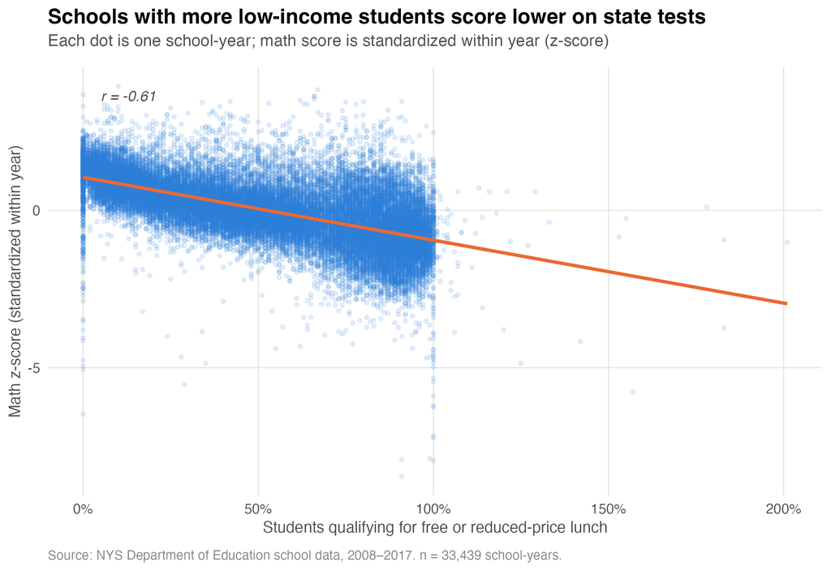

Every dot is one school in one year. Math z-score falls steadily as the share of students qualifying for free/reduced lunch rises (r = −0.61) — a strong, consistent relationship at the individual-school level, not just an artifact of averaging across counties.

### Performance by county poverty tier

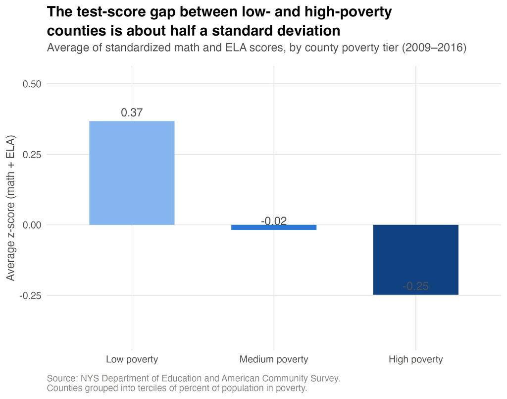

Low-poverty counties average +0.37 SD above the state mean; high-poverty counties average −0.25 SD below it — roughly a 0.6 SD gap. Medium-poverty counties sit almost exactly at the state average.

### Has the gap changed over time?

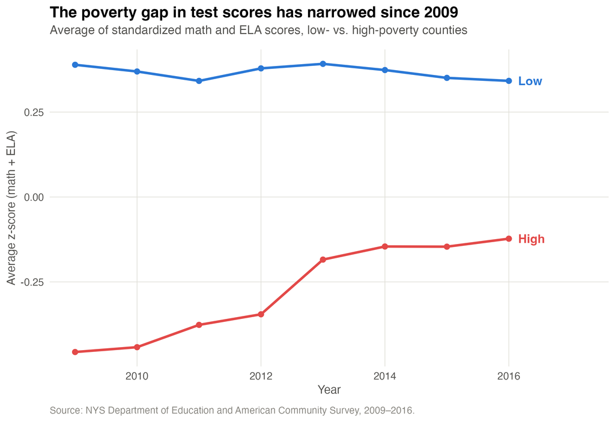

## Answering the department’s questions

**What does the data tell us about poverty and test performance, overall?** There’s a clear, sizeable negative relationship. At the school level, the share of students on free/reduced lunch correlates at r = −0.61 with math performance; at the county level, high-poverty counties trail low-poverty counties by roughly 0.6 SD in combined math/ELA performance.

**Has this relationship changed over time (2009–2016)?** Yes — it has narrowed. The low-poverty line is flat across the period; the high-poverty line rose steadily, especially between 2012 and 2013. Whatever changed (policy, funding, staffing, or the tests themselves), it shows up specifically in high-poverty counties’ scores, not in low-poverty counties.

## Caveats and recommendations

- **Coverage gap:** poverty tiers can’t be assigned for 2008 or 2017 (ACS data starts in 2009 and ends in 2016), so those two years are excluded from every poverty comparison above.
- **Ecological vs. individual level:** county poverty is a place-level measure; the lunch-access finding suggests school-level (or student-level) need is doing real, independent work beyond county averages, and would be worth investigating directly if student-level data becomes available.
- **Recommendation:** target interventions using school-level lunch-access data rather than county poverty tier alone — the moderation result shows county tier alone would misclassify plenty of individual schools.
- **Recommendation:** investigate what changed for high-poverty counties around 2012–2013, since whatever it was appears to be working and could be a candidate to expand or protect.